# EC2 CLC Data Analysis

AMP

2026-10-01

Coastal Land Conversion Project

Portions of the analytical workflow development and code refinement were assisted by an AI-based large language model (ChatGPT, OpenAI). The tool was used to support statistical model comparison strategies, cross-validation implementation, and reproducible R code structuring. All data processing, model execution, interpretation of results, and scientific conclusions were performed and verified by the authors. The authors take full responsibility for the integrity, accuracy, and interpretation of the analyses presented.

Rationale: to look at more localized drivers of VRR based on Molino et al., 2023 hypothesis that these are dependent on local drivers. https://agupubs.onlinelibrary.wiley.com/doi/full/10.1029/2023JG007525

Datasets:

1. vertical retreat rate

Dataset from: Chen and Kirwan 2023 https://onlinelibrary.wiley.com/doi/10.1111/gcb.17081 - vertical forest retreat rates for every point along the mid-Atlantic https://portal.edirepository.org/nis/mapbrowse?packageid=knb-lter-vcr.399.1

2. threshold elevations

Dataset from: Molino et al 2022 https://aslopubs.onlinelibrary.wiley.com/doi/10.1002/lol2.10262 - threshold elevation defining the boundary between forest and marsh, aggregated by watershed. This is only for Maryland and Virginia, so won’t work for EXCHANGE sites in DE or NJ https://portal.edirepository.org/nis/mapbrowse?packageid=knb-lter-vcr.343.2

3. Watershed parameters from Molino et al 2022
4. Soil parameters from EC1 v3

https://data.ess-dive.lbl.gov/view/doi%3A10.15485%2F1960313

Analysis to be completed in this script:

1. Multiple linear regression of vertical retreat rate vs. EC1 soil parameters
2. Multiple linear regression of threshold elevations vs. EC1 soil parameters (+ identified watershed parameters from Molino et al)

```r
library(readr)
library(dplyr)
```

```r
library(ggplot2)
library(car)
library(sf)
library(raster)
library(tidyverse)
```

### Load in all datasets:

```r
HUC14var <- read_csv("~/GitHub/EC2-Coastal-Land-Conversion/data_do_not_commit/knb-lter-vcr.387.1/VCR23383.csv", skip = 23)
colnames(HUC14var) <- c('FID', 'Watershed', 'Elevation', 'Tidal_Range', 'Surface_Salinity',  'Average_Slope',
                         'Isabel_maximum_inundation_depth', 'Isabel_Inundation_duration', 'Marsh_width', 'Watershed_area',
                         'TPI', 'Annual_temperature', 'Annual_precipitation', 'Annual_growing_season', 'WaterOccurrence',
                         'Change_WaterOccurrence', 'NDWI')
head(HUC14var)
```

```
## # A tibble: 6 × 17
##     FID Watershed           Elevation Tidal_Range Surface_Salinity Average_Slope
##   <dbl> <chr>                   <dbl>       <dbl>            <dbl>         <dbl>
## 1     3 Nansemond River         0.567        0.89           13.0            2.36
## 2     4 Powhatan Creek-Jam…     0.47         0.58            0.710          3.44
## 3     5 Pagan River-James …     0.487        0.79           11.0            2.71
## 4     6 Hampton Roads           0.456        0.79           15.4            2.67
## 5     8 Lower Tangier Sound     0.515        0.51           16.8            2.36
## 6     9 Marumsco Creek-Poc…     0.527        0.67           13.2            2.42
## # ℹ 11 more variables: Isabel_maximum_inundation_depth <dbl>,
## #   Isabel_Inundation_duration <dbl>, Marsh_width <dbl>, Watershed_area <dbl>,
## #   TPI <dbl>, Annual_temperature <dbl>, Annual_precipitation <dbl>,
## #   Annual_growing_season <dbl>, WaterOccurrence <dbl>,
## #   Change_WaterOccurrence <dbl>, NDWI <dbl>
```

For WRT: α is a scale parameter that is inversely proportional to the mean pore diameter; n is a shape parameter that controls the slope of the soil-water characteristic curve; θr is the residual water content, and θs is the saturated water content.

```r
#4. EC 1 Metadata
ec1_meta <-read_csv("~/GitHub/EC2-Coastal-Land-Conversion/data_do_not_commit/EC1 Package V3/data/ec1_metadata_v3/ec1_metadata_collectionlevel.csv")
ec1_meta_kit <-read_csv("~/GitHub/EC2-Coastal-Land-Conversion/data_do_not_commit/EC1 Package V3/data/ec1_metadata_v3/ec1_metadata_kitlevel.csv")
#EC 1 Soil Data
ec1_bd <- read_csv("~/GitHub/EC2-Coastal-Land-Conversion/data_do_not_commit/EC1 Package V3/data/ec1_soil_v3/ec1_soil_bulk_density_L2.csv") %>%
  dplyr::select(-igsn)
ec1_cond <- read_csv("~/GitHub/EC2-Coastal-Land-Conversion/data_do_not_commit/EC1 Package V3/data/ec1_soil_v3/ec1_soil_cond_L2.csv") %>%
    dplyr::select(-igsn)
ec1_gwc <- read_csv("~/GitHub/EC2-Coastal-Land-Conversion/data_do_not_commit/EC1 Package V3/data/ec1_soil_v3/ec1_soil_gwc_L2.csv") %>%
    dplyr::select(-igsn)
ec1_ph <- read_csv("~/GitHub/EC2-Coastal-Land-Conversion/data_do_not_commit/EC1 Package V3/data/ec1_soil_v3/ec1_soil_ph_L2.csv") %>%
    dplyr::select(-igsn)
ec1_mineralogy <- read_csv("~/GitHub/EC2-Coastal-Land-Conversion/data_do_not_commit/EC1 Package V3/data/ec1_soil_v3/ec1_soil_mineralogy_L2.csv") %>%
    dplyr::select(-igsn)
ec1_texture <- read_csv("~/GitHub/EC2-Coastal-Land-Conversion/data_do_not_commit/EC1 Package V3/data/ec1_soil_v3/ec1_soil_texture_L2.csv") %>%
   dplyr::select(-igsn)
ec1_wrc<- read_csv("~/GitHub/EC2-Coastal-Land-Conversion/data_do_not_commit/EC1 Package V3/data/ec1_soil_v3/ec1_soil_wrc_L2.csv") %>%
  dplyr::select(-igsn, -th_r, -n)
#EC 1 adjacent surface water data:
ec1_water_sal <- read_csv("~/GitHub/EC2-Coastal-Land-Conversion/data_do_not_commit/EC1 Package V3/data/ec1_water_v3/ec1_water_salinity_L2.csv") %>%
  rename(surface_water_sal_psu = sal_psu) %>%
  dplyr::select(kit_id, surface_water_sal_psu)
```

### Clean and merge datasets

#### EXCHANGE datasets and metadata

```
## # A tibble: 33 × 9
##    kit_id region      transect_location site_name latitude longitude elevation_m
##    <chr>  <chr>       <chr>             <chr>        <dbl>     <dbl>       <dbl>
##  1 K015   Mid-Atlant… upland            Taskinas…     37.4     -76.7        0.7
##  2 K016   Mid-Atlant… upland            Transect…     37.3     -76.6        1.01
##  3 K017   Mid-Atlant… upland            Transect…     37.6     -76.9        0.84
##  4 K018   Mid-Atlant… upland            Goodwin …     37.2     -76.4        1.1
##  5 K023   Mid-Atlant… upland            Jug Bay-…     38.8     -76.7       10.4
##  6 K024   Mid-Atlant… upland            Monie Ba…     38.2     -75.8        0.91
##  7 K025   Mid-Atlant… upland            Muddy Cr…     38.9     -76.6        0.76
##  8 K026   Mid-Atlant… upland            Lang Far…     37.7     -75.6        1.37
##  9 K027   Mid-Atlant… upland            Greenhea…     38.0     -75.8        0.69
## 10 K029   Mid-Atlant… upland            Gum Tree…     39.4     -75.4        1.38
## # ℹ 23 more rows
## # ℹ 2 more variables: soil_type <chr>, soil_horizon <chr>
```

```
## # A tibble: 32 × 29
##    campaign kit_id transect_location bulk_density_g_cm3 specific_conductance_u…¹
##    <chr>    <chr>  <chr>                          <dbl>                    <dbl>
##  1 EC1      K015   upland                         0.907                     77
##  2 EC1      K016   upland                         0.146                   1820
##  3 EC1      K017   upland                         0.755                     33.8
##  4 EC1      K023   upland                         0.428                    138
##  5 EC1      K024   upland                         0.242                   1630
##  6 EC1      K025   upland                         0.702                    105
##  7 EC1      K026   upland                         1.55                      77.8
##  8 EC1      K027   upland                         1.48                      NA
##  9 EC1      K030   upland                         0.177                    617
## 10 EC1      K034   upland                         0.907                    390
## # ℹ 22 more rows
## # ℹ abbreviated name: ¹specific_conductance_us_cm
## # ℹ 24 more variables: moisturecontent_perc_drywtbasis <dbl>, ph <dbl>,
## #   albite <dbl>, chlorite <dbl>, dolomite <dbl>, halite <dbl>,
## #   hornblende <dbl>, kaolinite <dbl>, microcline <dbl>, muscovite <dbl>,
## #   pyrite <dbl>, quartz <dbl>, percent_clay <dbl>, percent_sand <dbl>,
## #   percent_silt <dbl>, alpha <dbl>, th_s <dbl>, region <chr>, …
```

#### Vertical Forest Retreat Rate

Projected Coordinate Reference System (CRS) “WGS 84 / UTM zone 18N” = EPSG code for this CRS is 32618.

### dataframe with all EC1 data, Molino data for Vertical Retreat Rate:

```
##    kit_id transect_location  V_RetreatR campaign bulk_density_g_cm3
## 1    K015            upland  3.90574376      EC1          0.9068754
## 2    K016            upland  7.28291464      EC1          0.1456621
## 3    K017            upland  0.43244526      EC1          0.7546296
## 4    K023            upland  6.67471118      EC1          0.4283784
## 5    K024            upland  8.31076238      EC1          0.2422311
## 6    K025            upland  3.18848757      EC1          0.7024590
## 7    K026            upland 12.73086589      EC1          1.5536364
## 8    K027            upland  1.87225100      EC1          1.4757040
## 9    K029            upland  1.80071739      EC1                 NA
## 10   K030            upland  3.27676435      EC1          0.1773675
## 11   K035            upland  0.01000000      EC1          0.8721815
## 12   K036            upland  3.41421967      EC1          0.2102817
## 13   K040            upland  0.06100773      EC1          0.1066667
## 14   K041            upland  0.06100773      EC1          0.1063895
```

[output cut: 161 more lines]

#### Threshold Elevations

Projected CRS: NAD83 / UTM zone 18N = crs epsg 26918 aka should be the same as st_crs(HUC_shp)

### dataframe with all EC1 data for Threshold Elevation:

```
## # A tibble: 19 × 32
##    kit_id transect_location name           Elevation campaign bulk_density_g_cm3
##    <chr>  <chr>             <chr>              <dbl> <chr>                 <dbl>
##  1 K015   upland            Upper York Ri…     0.647 EC1                   0.907
##  2 K016   upland            Lower York Ri…     0.537 EC1                   0.146
##  3 K017   upland            Lower Pamunke…     0.337 EC1                   0.755
##  4 K023   upland            Middle Patuxe…     0.467 EC1                   0.428
##  5 K024   upland            Wicomico River     0.582 EC1                   0.242
##  6 K025   upland            Herring Bay-F…     0.600 EC1                   0.702
##  7 K026   upland            Metompkin Bay…     0.712 EC1                   1.55
##  8 K027   upland            Marumsco Cree…     0.527 EC1                   1.48
##  9 K034   upland            Huntington Cr…     0.460 EC1                   0.907
## 10 K035   upland            Choptank Rive…     0.545 EC1                   0.872
## 11 K036   upland            Fairlee Creek…     0.62  EC1                   0.210
## 12 K040   upland            Machipongo Ri…     1.05  EC1                   0.107
## 13 K041   upland            Machipongo Ri…     1.05  EC1                   0.106
## 14 K044   upland            Herring Bay-F…     0.600 EC1                   0.548
## 15 K051   upland            Little Chopta…     0.476 EC1                   1.37
## 16 K052   upland            Manokin River…     0.598 EC1                   1.45
## 17 K053   upland            Upper Patuxen…     0.460 EC1                   0.993
## 18 K059   upland            Honga River-F…     0.475 EC1                   0.155
## 19 K062   upland            Herring Bay-F…     0.600 EC1                   0.773
## # ℹ 26 more variables: specific_conductance_us_cm <dbl>,
## #   moisturecontent_perc_drywtbasis <dbl>, ph <dbl>, albite <dbl>,
## #   chlorite <dbl>, dolomite <dbl>, halite <dbl>, hornblende <dbl>,
## #   kaolinite <dbl>, microcline <dbl>, muscovite <dbl>, pyrite <dbl>,
## #   quartz <dbl>, percent_clay <dbl>, percent_sand <dbl>, percent_silt <dbl>,
## #   alpha <dbl>, th_s <dbl>, region <chr>, site_name <chr>, latitude <dbl>,
## #   longitude <dbl>, elevation_m <dbl>, soil_type <chr>, soil_horizon <chr>, …
```

### dataframe with all EC1 data for Threshold Elevation including signficant watershed variables from Molino et al:

```
## # A tibble: 19 × 35
##    kit_id transect_location name           Elevation campaign bulk_density_g_cm3
##    <chr>  <chr>             <chr>              <dbl> <chr>                 <dbl>
##  1 K015   upland            Upper York Ri…     0.647 EC1                   0.907
##  2 K016   upland            Lower York Ri…     0.537 EC1                   0.146
##  3 K017   upland            Lower Pamunke…     0.337 EC1                   0.755
##  4 K023   upland            Middle Patuxe…     0.467 EC1                   0.428
##  5 K024   upland            Wicomico River     0.582 EC1                   0.242
##  6 K025   upland            Herring Bay-F…     0.600 EC1                   0.702
##  7 K026   upland            Metompkin Bay…     0.712 EC1                   1.55
##  8 K027   upland            Marumsco Cree…     0.527 EC1                   1.48
##  9 K034   upland            Huntington Cr…     0.460 EC1                   0.907
## 10 K035   upland            Choptank Rive…     0.545 EC1                   0.872
## 11 K036   upland            Fairlee Creek…     0.62  EC1                   0.210
## 12 K040   upland            Machipongo Ri…     1.05  EC1                   0.107
## 13 K041   upland            Machipongo Ri…     1.05  EC1                   0.106
## 14 K044   upland            Herring Bay-F…     0.600 EC1                   0.548
## 15 K051   upland            Little Chopta…     0.476 EC1                   1.37
## 16 K052   upland            Manokin River…     0.598 EC1                   1.45
## 17 K053   upland            Upper Patuxen…     0.460 EC1                   0.993
## 18 K059   upland            Honga River-F…     0.475 EC1                   0.155
## 19 K062   upland            Herring Bay-F…     0.600 EC1                   0.773
## # ℹ 29 more variables: specific_conductance_us_cm <dbl>,
## #   moisturecontent_perc_drywtbasis <dbl>, ph <dbl>, albite <dbl>,
## #   chlorite <dbl>, dolomite <dbl>, halite <dbl>, hornblende <dbl>,
## #   kaolinite <dbl>, microcline <dbl>, muscovite <dbl>, pyrite <dbl>,
## #   quartz <dbl>, percent_clay <dbl>, percent_sand <dbl>, percent_silt <dbl>,
## #   alpha <dbl>, th_s <dbl>, region <chr>, site_name <chr>, latitude <dbl>,
## #   longitude <dbl>, elevation_m <dbl>, soil_type <chr>, soil_horizon <chr>, …
```

```
## # A tibble: 11 × 4
##    var                             n_total n_nonmiss n_with_Elev
##    <chr>                             <int>     <int>       <int>
##  1 Elevation                            19        19          19
##  2 moisturecontent_perc_drywtbasis      19        19          19
##  3 bulk_density_g_cm3                   19        19          19
##  4 surface_water_sal_psu                19        19          19
##  5 specific_conductance_us_cm           19        18          18
##  6 Tidal_Range                          19        17          17
##  7 Surface_Salinity                     19        17          17
##  8 Average_Slope                        19        17          17
##  9 percent_clay                         19        15          15
## 10 th_s                                 19        13          13
## 11 alpha                                19        13          13
```

missing HUC14 data for: - Upper Patuxent River - Huntington Creek-Choptank River

Need to confirm with Matt/Grace if we can substitute others in or not.

# Refit original model with just macro variables on just the 17 sites that overlap with EXCHANGE data.

From Molino et al https://agupubs.onlinelibrary.wiley.com/doi/full/10.1029/2023JG007525 Variable p-value Coefficient Resolution Source Tidal range 0.001 0.2264 400 m NOAA%20%20VDatum Surface salinity 0.000 0.0083 600 m St-Laurent et al. (2020) Average slope 0.003 0.1304 30 m Molino et al. (2020)

```r
d17 <- clc_all_data_ws_sigcors %>%
  group_by(name) %>%
  dplyr::select(Elevation,
         Surface_Salinity,
         Tidal_Range,
         Average_Slope,
         surface_water_sal_psu,
         moisturecontent_perc_drywtbasis,
         bulk_density_g_cm3,
         specific_conductance_us_cm) %>%
  drop_na() %>%
  ungroup() %>%
  dplyr::select(-name)
d17
```

```
## # A tibble: 16 × 8
##    Elevation Surface_Salinity Tidal_Range Average_Slope surface_water_sal_psu
##        <dbl>            <dbl>       <dbl>         <dbl>                 <dbl>
##  1     0.647             5.84        0.85          2.70                 16.0
##  2     0.537            15.5         0.74          2.58                 20.5
##  3     0.337             1.41        0.89          3.16                  2.7
##  4     0.467             2.14        0.48          3.03                  0.2
##  5     0.582            10.9         0.66          2.60                 12.9
##  6     0.600            10.1         0.3           2.96                  2.65
##  7     0.712            32.1         1.12          2.51                 31.9
##  8     0.545            10.7         0.42          3.08                 11.0
##  9     0.62              7.17        0.35          3.00                  6.6
## 10     1.05             31.8         1.18          1.97                 32.6
## 11     1.05             31.8         1.18          1.97                 33.3
## 12     0.600            10.1         0.3           2.96                  5.11
## 13     0.476            11.5         0.38          2.69                 12.2
## 14     0.598            15.4         0.6           2.58                 15.1
## 15     0.475            14.2         0.47          2.67                 12.5
## 16     0.600            10.1         0.3           2.96                  7.54
## # ℹ 3 more variables: moisturecontent_perc_drywtbasis <dbl>,
## #   bulk_density_g_cm3 <dbl>, specific_conductance_us_cm <dbl>
```

```r
cor(d17[, c("Elevation","Tidal_Range","Surface_Salinity","Average_Slope")])
```

```
##                   Elevation Tidal_Range Surface_Salinity Average_Slope
## Elevation         1.0000000   0.6152776        0.8194061    -0.8366854
## Tidal_Range       0.6152776   1.0000000        0.6844671    -0.7347681
## Surface_Salinity  0.8194061   0.6844671        1.0000000    -0.8679704
## Average_Slope    -0.8366854  -0.7347681       -0.8679704     1.0000000
```

Macro variables are highly co-correlated in the subset data, so pick the one with the highest correlation to elevation. This is actually slope, not salinity

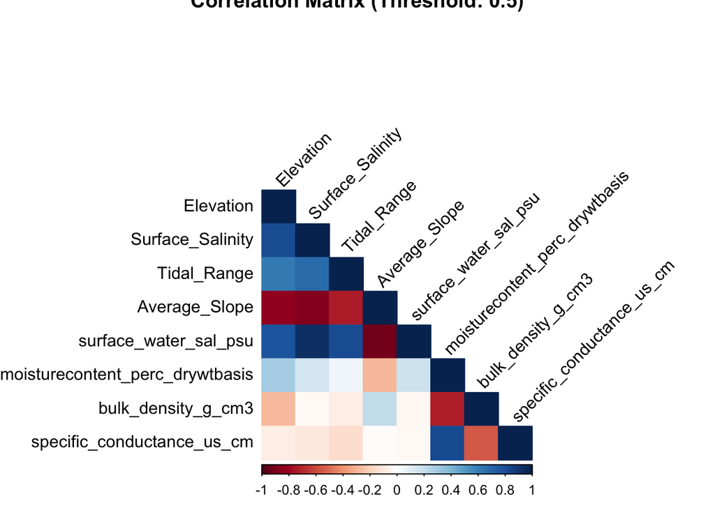

```r
corr_matrix <- cor(d17, method = "pearson") # Uses pairs only when we have complete observations

# Print the correlation matrix using corrplot
library(corrplot) # Needed for the correlation plot
corrplot(corr_matrix, method = "color", type = "lower", tl.col = "black", tl.srt = 45, title = sprintf("Correlation Matrix (Threshold: %s)", corr_threshold = 0.5))
```

```r
labels <- c(
 # Surface_Salinity = "Watershed Average Salinity (PSU)",
  #Tidal_Range = "Tidal Range",
 # Average_Slope = "Average Slope",
  surface_water_sal_psu = "Surface Water Salinity \n (PSU)",
  moisturecontent_perc_drywtbasis = "Soil Moisture Content \n (% w/w)",
  bulk_density_g_cm3 = "Soil Bulk Density \n (g/cm³)",
  specific_conductance_us_cm = "Soil Specific Conductance \n (µS/cm)"
)

corr_df <- data.frame(corr_matrix["Elevation", -1]) %>%
  rename(Correlation_w_Elevation = 'corr_matrix..Elevation....1.') %>%
  rownames_to_column(var = "Variable") %>%
  filter(Variable != c("Surface_Salinity", "Tidal_Range", "Average_Slope"))
```

```r
plot_corr <- ggplot(corr_df,
       aes(x = reorder(Variable, Correlation_w_Elevation),
           y = Correlation_w_Elevation,
           fill= Variable)) +
  geom_col(alpha=0.7) +
  coord_flip() +
  theme_classic() +
  ylab("Pearson Correlation with Threshold Elevation") +
  xlab("EC1 Measured Variable") +
  scale_x_discrete(labels = labels)+
 # scale_fill_manual(values = soilpalettes::soil_palette("redox2", 9)) +
  theme(legend.position = "none")

corr_df
```

```
##                          Variable Correlation_w_Elevation
## 1           surface_water_sal_psu              0.78813312
## 2 moisturecontent_perc_drywtbasis              0.29050176
## 3              bulk_density_g_cm3             -0.27551508
## 4      specific_conductance_us_cm             -0.07642738
```

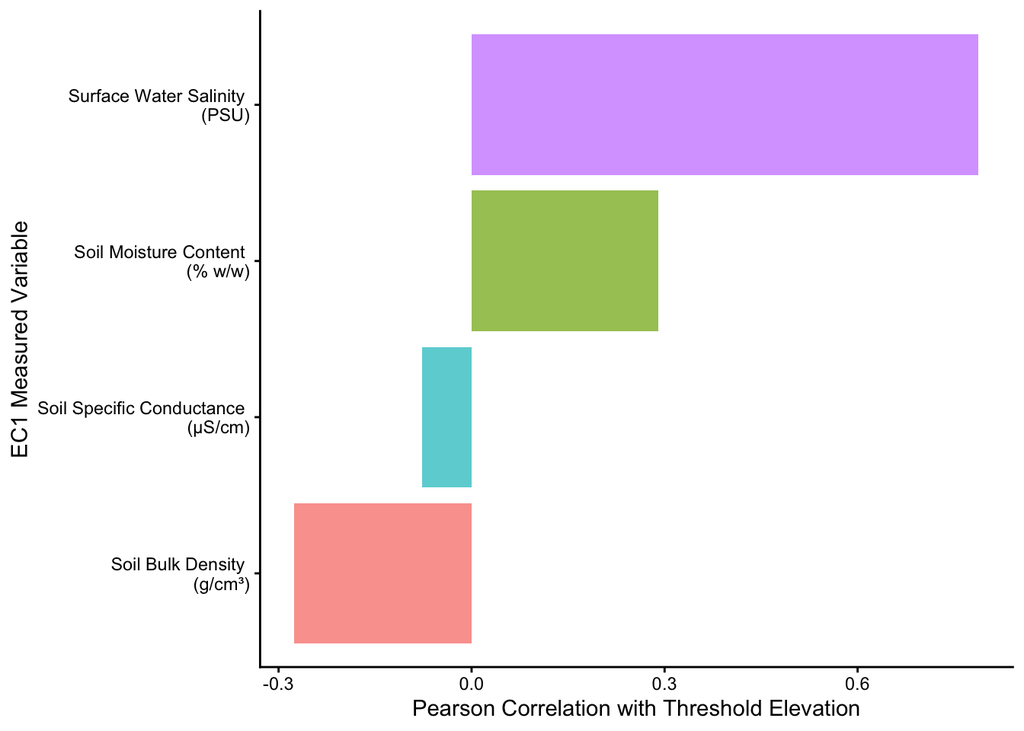

```r
plot_corr
```

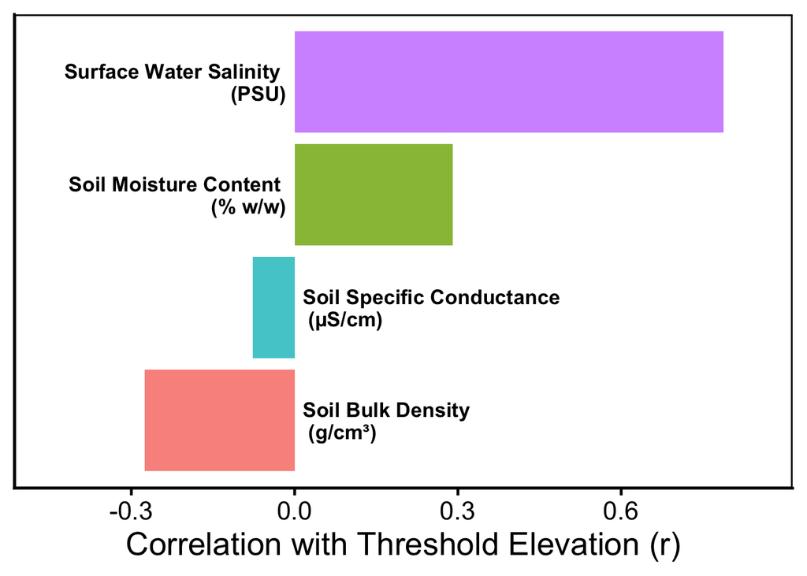

```r
plot_corr <- ggplot(
  corr_df,
  aes(
    x = reorder(Variable, Correlation_w_Elevation),
    y = Correlation_w_Elevation,
    fill = Variable
  )
) +
  geom_col(alpha = 0.8) +

  geom_text(
    aes(
      y = ifelse(Correlation_w_Elevation > 0, -0.015, 0.015),
      label = labels[match(Variable, names(labels))],
      hjust = ifelse(Correlation_w_Elevation > 0, 1, 0)
    ),
    color = "black",
    size = 4.5,
    fontface = "bold",
    lineheight = 0.9
  ) +

  coord_flip() +

  scale_y_continuous(
    limits = c(-0.45, 0.85),
    breaks = c(-0.3, 0, 0.3, 0.6)
  ) +

  scale_x_discrete(labels = NULL) +

 # scale_fill_manual(
  #  values = soilpalettes::soil_palette("redox2", 9)
#  ) +

  labs(
    x = NULL,
    y = "Correlation with Threshold Elevation (r)"
  ) +

  theme_classic(base_size = 18) +

  theme(
    legend.position = "none",
    axis.text.y = element_blank(),
    axis.ticks.y = element_blank(),
    axis.title.x = element_text(size = 20),
    axis.text.x = element_text(size = 16),
    panel.border = element_rect(
      color = "black",
      fill = NA,
      linewidth = 1
    )
  )


plot_corr
```

```r
#ggsave("corr_matrix_forproposal.png", plot = plot_corr)
```

```r
loocv_rmse <- function(formula, data) {
  fit <- lm(formula, data = data, na.action = na.omit)
  loo_errors <- residuals(fit) / (1 - hatvalues(fit))
  sqrt(mean(loo_errors^2))
}
```

```r
m_macro_ws <- lm(Elevation ~ Average_Slope, data = d17)
summary(m_macro_ws)
```

```
##
## Call:
## lm(formula = Elevation ~ Average_Slope, data = d17)
##
## Residuals:
##      Min       1Q   Median       3Q      Max
## -0.16355 -0.08491  0.01152  0.09234  0.12846
##
## Coefficients:
##               Estimate Std. Error t value Pr(>|t|)
## (Intercept)    1.83829    0.21504   8.549 6.28e-07 ***
## Average_Slope -0.44916    0.07858  -5.716 5.33e-05 ***
## ---
## Signif. codes:  0 '***' 0.001 '**' 0.01 '*' 0.05 '.' 0.1 ' ' 1
##
## Residual standard error: 0.1081 on 14 degrees of freedom
## Multiple R-squared:    0.7,  Adjusted R-squared:  0.6786
## F-statistic: 32.67 on 1 and 14 DF,  p-value: 5.333e-05
```

```r
loocv_rmse(Elevation ~ Average_Slope, d17)
```

```
## [1] 0.1173428
```

```r
m_micro_ws <- lm(Elevation ~ surface_water_sal_psu +
                               moisturecontent_perc_drywtbasis,
                 data = d17)

summary(m_micro_ws)
```

```
##
## Call:
## lm(formula = Elevation ~ surface_water_sal_psu + moisturecontent_perc_drywtbasis,
##     data = d17)
##
## Residuals:
##      Min       1Q   Median       3Q      Max
## -0.18484 -0.09845  0.00292  0.08933  0.16447
##
## Coefficients:
##                                  Estimate Std. Error t value Pr(>|t|)
## (Intercept)                     0.4015291  0.0561128   7.156 7.41e-06 ***
## surface_water_sal_psu           0.0135196  0.0029794   4.538 0.000558 ***
## moisturecontent_perc_drywtbasis 0.0003651  0.0003852   0.948 0.360482
## ---
## Signif. codes:  0 '***' 0.001 '**' 0.01 '*' 0.05 '.' 0.1 ' ' 1
##
## Residual standard error: 0.1219 on 13 degrees of freedom
## Multiple R-squared:  0.6456, Adjusted R-squared:  0.5911
## F-statistic: 11.84 on 2 and 13 DF,  p-value: 0.001179
```

```r
m_combo_ws <- lm(Elevation ~ Average_Slope +
                               surface_water_sal_psu +
                               moisturecontent_perc_drywtbasis,
                 data = d17)

summary(m_combo_ws)
```

```
##
## Call:
## lm(formula = Elevation ~ Average_Slope + surface_water_sal_psu +
##     moisturecontent_perc_drywtbasis, data = d17)
##
## Residuals:
##      Min       1Q   Median       3Q      Max
## -0.17101 -0.07900  0.01711  0.09506  0.11484
##
## Coefficients:
##                                   Estimate Std. Error t value Pr(>|t|)
## (Intercept)                      1.4829469  0.6700739   2.213    0.047 *
## Average_Slope                   -0.3412276  0.2107731  -1.619    0.131
## surface_water_sal_psu            0.0035249  0.0067828   0.520    0.613
## moisturecontent_perc_drywtbasis  0.0001664  0.0003834   0.434    0.672
## ---
## Signif. codes:  0 '***' 0.001 '**' 0.01 '*' 0.05 '.' 0.1 ' ' 1
##
## Residual standard error: 0.1149 on 12 degrees of freedom
## Multiple R-squared:  0.7092, Adjusted R-squared:  0.6365
## F-statistic: 9.754 on 3 and 12 DF,  p-value: 0.001537
```

```r
loocv_rmse(Elevation ~ surface_water_sal_psu +
                           moisturecontent_perc_drywtbasis, d17)
```

```
## [1] 0.1390578
```

```r
loocv_rmse(Elevation ~ Average_Slope +
                           surface_water_sal_psu +
                           moisturecontent_perc_drywtbasis, d17)
```

```
## [1] 0.1416052
```

Try on the subset with the soil hydraulic info

```r
d13 <- clc_all_data_ws_sigcors %>%
  dplyr::select(Elevation,
         Average_Slope,
         th_s,
         alpha) %>%
  drop_na()

m_macro13 <- lm(Elevation ~ Average_Slope, data = d13)
m_micro13 <- lm(Elevation ~ th_s + alpha, data = d13)
m_combo13 <- lm(Elevation ~ Average_Slope + th_s + alpha, data = d13)

summary(m_macro13)
```

```
##
## Call:
## lm(formula = Elevation ~ Average_Slope, data = d13)
##
## Residuals:
##      Min       1Q   Median       3Q      Max
## -0.18175 -0.10458  0.03356  0.07490  0.19091
##
## Coefficients:
##               Estimate Std. Error t value Pr(>|t|)
## (Intercept)     1.5369     0.3361   4.573  0.00134 **
## Average_Slope  -0.3416     0.1244  -2.746  0.02261 *
## ---
## Signif. codes:  0 '***' 0.001 '**' 0.01 '*' 0.05 '.' 0.1 ' ' 1
##
## Residual standard error: 0.1243 on 9 degrees of freedom
## Multiple R-squared:  0.4559, Adjusted R-squared:  0.3955
## F-statistic: 7.542 on 1 and 9 DF,  p-value: 0.02261
```

```r
summary(m_micro13)
```

```
##
## Call:
## lm(formula = Elevation ~ th_s + alpha, data = d13)
##
## Residuals:
##      Min       1Q   Median       3Q      Max
## -0.19509 -0.07861 -0.02508  0.05190  0.35407
##
## Coefficients:
##             Estimate Std. Error t value Pr(>|t|)
## (Intercept)   0.7157     0.3240   2.209   0.0582 .
## th_s         -0.4230     0.8444  -0.501   0.6299
## alpha         0.9528     0.8368   1.139   0.2878
## ---
## Signif. codes:  0 '***' 0.001 '**' 0.01 '*' 0.05 '.' 0.1 ' ' 1
##
## Residual standard error: 0.1658 on 8 degrees of freedom
## Multiple R-squared:  0.1396, Adjusted R-squared:  -0.07555
## F-statistic: 0.6488 on 2 and 8 DF,  p-value: 0.5481
```

```r
summary(m_combo13)
```

```
##
## Call:
## lm(formula = Elevation ~ Average_Slope + th_s + alpha, data = d13)
##
## Residuals:
##      Min       1Q   Median       3Q      Max
## -0.18394 -0.09493  0.04718  0.05530  0.14035
##
## Coefficients:
##               Estimate Std. Error t value Pr(>|t|)
## (Intercept)     1.6180     0.4342   3.727  0.00739 **
## Average_Slope  -0.3274     0.1288  -2.541  0.03861 *
## th_s           -0.4475     0.6511  -0.687  0.51400
## alpha           0.7916     0.6484   1.221  0.26166
## ---
## Signif. codes:  0 '***' 0.001 '**' 0.01 '*' 0.05 '.' 0.1 ' ' 1
##
## Residual standard error: 0.1278 on 7 degrees of freedom
## Multiple R-squared:  0.5524, Adjusted R-squared:  0.3606
## F-statistic:  2.88 on 3 and 7 DF,  p-value: 0.1126
```

```r
loocv_rmse(Elevation ~ Average_Slope, d13)
```

```
## [1] 0.1811715
```

```r
loocv_rmse(Elevation ~ th_s + alpha, d13)
```

```
## [1] 0.2009571
```

```r
loocv_rmse(Elevation ~ Average_Slope + th_s + alpha, d13)
```

```
## [1] 0.2146733
```

tl;dr is that the local site characteristics aggregated at the watershed scale/using watershed scale threshold elevations doesn’t add in significant explanatory power over the watershed scale variables. Let’s summarize this for KPs perspectives paper. s ## summarize

```r
# ============================================================
# Summary table: macro vs local vs combined predictive models
# ============================================================

library(dplyr)
library(tibble)

# Helper function to summarize lm models + LOOCV RMSE
summarize_model <- function(model, model_name, predictors, data, formula) {

  sm <- summary(model)

  tibble(
    Model = model_name,
    n = nobs(model),
    Predictors = predictors,
    R2 = sm$r.squared,
    Adj_R2 = sm$adj.r.squared,
    LOOCV_RMSE = loocv_rmse(formula, data)
  )
}

# ---- Models using the larger complete-case subset ----

model_summary_d17 <- bind_rows(

  summarize_model(
    m_macro_ws,
    model_name = "Watershed-scale",
    predictors = "Average slope",
    data = d17,
    formula = Elevation ~ Average_Slope
  ),

  summarize_model(
    m_micro_ws,
    model_name = "Local",
    predictors = "Surface-water salinity + soil moisture",
    data = d17,
    formula = Elevation ~ surface_water_sal_psu +
      moisturecontent_perc_drywtbasis
  ),

  summarize_model(
    m_combo_ws,
    model_name = "Combined",
    predictors = "Average slope + surface-water salinity + soil moisture",
    data = d17,
    formula = Elevation ~ Average_Slope +
      surface_water_sal_psu +
      moisturecontent_perc_drywtbasis
  )
)

model_summary_d17
```

```
## # A tibble: 3 × 6
##   Model               n Predictors                          R2 Adj_R2 LOOCV_RMSE
##   <chr>           <int> <chr>                            <dbl>  <dbl>      <dbl>
## 1 Watershed-scale    16 Average slope                    0.700  0.679      0.117
## 2 Local              16 Surface-water salinity + soil m… 0.646  0.591      0.139
## 3 Combined           16 Average slope + surface-water s… 0.709  0.636      0.142
```

```r
# ---- Models using subset with soil hydraulic properties ----

model_summary_d13 <- bind_rows(

  summarize_model(
    m_macro13,
    model_name = "Watershed-scale",
    predictors = "Average slope",
    data = d13,
    formula = Elevation ~ Average_Slope
  ),

  summarize_model(
    m_micro13,
    model_name = "Local hydraulic",
    predictors = "Saturated water content (theta_s) + alpha",
    data = d13,
    formula = Elevation ~ th_s + alpha
  ),

  summarize_model(
    m_combo13,
    model_name = "Combined",
    predictors = "Average slope + theta_s + alpha",
    data = d13,
    formula = Elevation ~ Average_Slope + th_s + alpha
  )
)

model_summary_d13
```

```
## # A tibble: 3 × 6
##   Model               n Predictors                         R2  Adj_R2 LOOCV_RMSE
##   <chr>           <int> <chr>                           <dbl>   <dbl>      <dbl>
## 1 Watershed-scale    11 Average slope                   0.456  0.395       0.181
## 2 Local hydraulic    11 Saturated water content (theta… 0.140 -0.0755      0.201
## 3 Combined           11 Average slope + theta_s + alpha 0.552  0.361       0.215
```

```r
model_comparison_table <- bind_rows(
  model_summary_d17 %>% mutate(Data_subset = "Local soil/water variables"),
  model_summary_d13 %>% mutate(Data_subset = "Soil hydraulic variables")
) %>%
  dplyr::select(
    Data_subset,
    Model,
    n,
    Predictors,
    R2,
    Adj_R2,
    LOOCV_RMSE
  ) %>%
  mutate(
    across(c(R2, Adj_R2, LOOCV_RMSE), ~ round(.x, 3))
  )

model_comparison_table
```

```
## # A tibble: 6 × 7
##   Data_subset                Model          n Predictors    R2 Adj_R2 LOOCV_RMSE
##   <chr>                      <chr>      <int> <chr>      <dbl>  <dbl>      <dbl>
## 1 Local soil/water variables Watershed…    16 Average s… 0.7    0.679      0.117
## 2 Local soil/water variables Local         16 Surface-w… 0.646  0.591      0.139
## 3 Local soil/water variables Combined      16 Average s… 0.709  0.636      0.142
## 4 Soil hydraulic variables   Watershed…    11 Average s… 0.456  0.395      0.181
## 5 Soil hydraulic variables   Local hyd…    11 Saturated… 0.14  -0.076      0.201
## 6 Soil hydraulic variables   Combined      11 Average s… 0.552  0.361      0.215
```

```r
knitr::kable(
  model_comparison_table,
  caption = "Comparison of watershed-scale, local, and combined models of marsh–forest threshold elevation.",
  align = c("l", "l", "c", "l", "c", "c", "c")
)
```

Comparison of watershed-scale, local, and combined models of marsh–forest threshold elevation.

| Data_subset | Model | n | Predictors | R2 | Adj_R2 | LOOCV_RMSE |
| --- | --- | --- | --- | --- | --- | --- |
| Local soil/water variables | Watershed-scale | 16 | Average slope | 0.700 | 0.679 | 0.117 |
| Local soil/water variables | Local | 16 | Surface-water salinity + soil moisture | 0.646 | 0.591 | 0.139 |
| Local soil/water variables | Combined | 16 | Average slope + surface-water salinity + soil moisture | 0.709 | 0.636 | 0.142 |
| Soil hydraulic variables | Watershed-scale | 11 | Average slope | 0.456 | 0.395 | 0.181 |
| Soil hydraulic variables | Local hydraulic | 11 | Saturated water content (theta_s) + alpha | 0.140 | -0.076 | 0.201 |
| Soil hydraulic variables | Combined | 11 | Average slope + theta_s + alpha | 0.552 | 0.361 | 0.215 |

```r
# ============================================================
# Variable coverage table
# ============================================================

coverage_table <- coverage %>%
  mutate(
    Percent_with_Elevation =
      round(100 * n_with_Elev / n_total, 1)
  ) %>%
  dplyr::select(
    Variable = var,
    Total_sites = n_total,
    Nonmissing = n_nonmiss,
    Usable_with_threshold_elevation = n_with_Elev,
    Percent_with_Elevation
  )

knitr::kable(
  coverage_table,
  caption = "Availability of regional and local predictor variables at sites with threshold-elevation data."
)
```

Availability of regional and local predictor variables at sites with threshold-elevation data.

| Variable | Total_sites | Nonmissing | Usable_with_threshold_elevation | Percent_with_Elevation |
| --- | --- | --- | --- | --- |
| Elevation | 19 | 19 | 19 | 100.0 |
| moisturecontent_perc_drywtbasis | 19 | 19 | 19 | 100.0 |
| bulk_density_g_cm3 | 19 | 19 | 19 | 100.0 |
| surface_water_sal_psu | 19 | 19 | 19 | 100.0 |
| specific_conductance_us_cm | 19 | 18 | 18 | 94.7 |
| Tidal_Range | 19 | 17 | 17 | 89.5 |
| Surface_Salinity | 19 | 17 | 17 | 89.5 |
| Average_Slope | 19 | 17 | 17 | 89.5 |
| percent_clay | 19 | 15 | 15 | 78.9 |
| th_s | 19 | 13 | 13 | 68.4 |
| alpha | 19 | 13 | 13 | 68.4 |

Now, lets find and aggregate some watershed scale soil properties! # Part 2: Database data

```r
library(sf)
library(soilDB)
library(terra)

HUC_shp_ea <- st_transform(HUC_shp, 5070)

# 1) Request mukey grid again (start a bit coarser if needed)
mukey_r <- mukey.wcs(aoi = HUC_shp_ea, db = "gSSURGO", res = 150)

# 2) Convert -> write to disk -> read back (forces values to exist)
tmp <- tempfile(fileext = ".tif")
writeRaster(rast(mukey_r), tmp, overwrite = TRUE)

mukey_rast <- rast(tmp)

# 3) Confirm it now has values
hasValues(mukey_rast)
global(mukey_rast, "notNA", na.rm = TRUE)
```

bulk density (dbthirdbar_r) clay (claytotal_r) sand (sandtotal_r) available water capacity (awc_r)

```r
vars <- c("dbthirdbar_r", "claytotal_r", "sandtotal_r", "awc_r")

# Example: fetch property table for mukeys you have in your grid
# (you’ll need to extract unique mukeys from the mukey raster first)
mukeys <- sort(unique(values(mukey_rast)))
mukeys <- mukeys[!is.na(mukeys)]

prop <- get_SDA_property(
  mukeys = mukeys,
  property = vars,
  top_depth = 0,
  bottom_depth = 30,
  method = "Dominant Component",
  agg.method = "Depth Weighted Average"
)
```